# Loan Data

Hamid Shafiezadeh

### Objective

The purpose of this project is to explore a data set to build a model for estimating the probability of default of borrowers. The model helps banks to evaluate the credit risk of borrowers. The project is organized as follows: first, a dataset that consists of data from almost 10,000 borrowers is explored, where some borrowers paid their loans back and others are still in progress. Second, a payment schedule is suggested under a simple scenario for those who did not fully pay their loans. Finally, a model is presented to estimate the likelihood of payment.

### Load packages

```r
library(skimr)
library(tidyverse)
library(dplyr)
library(purrr)
library(pROC)
library(stargazer)
library(ggpubr)
library(reshape2)
library(knitr)
```

### Data

The data is extracted from lendingclub.com which is an organization that connects borrowers with investors. ([source](https://www.kaggle.com/itssuru/loan-data))

```r
loans <- readr::read_csv('data/loans.csv.gz')
```

The table shows variables in the data set with their description.

| Variable | description |
| --- | --- |
| credit_policy | 1 if the customer meets the credit underwriting criteria; 0 otherwise. |
| purpose | The purpose of the loan. |
| int_rate | The interest rate of the loan (more risky borrowers are assigned higher interest rates). |
| installment | The monthly installments owed by the borrower if the loan is funded. |
| log_annual_inc | The natural log of the self-reported annual income of the borrower. |
| dti | The debt-to-income ratio of the borrower (amount of debt divided by annual income). |
| fico | The FICO credit score of the borrower. |
| days_with_cr_line | The number of days the borrower has had a credit line. |
| revol_bal | The borrower’s revolving balance (amount unpaid at the end of the credit card billing cycle). |
| revol_util | The borrower’s revolving line utilization rate (the amount of the credit line used relative to total credit available). |
| inq_last_6mths | The borrower’s number of inquiries by creditors in the last 6 months. |
| delinq_2yrs | The number of times the borrower had been 30+ days past due on a payment in the past 2 years. |
| pub_rec | The borrower’s number of derogatory public records. |
| not_fully_paid | 1 if the loan is not fully paid; 0 otherwise. |

### Data description

The plot shows the majority of borrowers in data set pays their loans in full amount, around 1500 borrowers did not fully paid their debt.

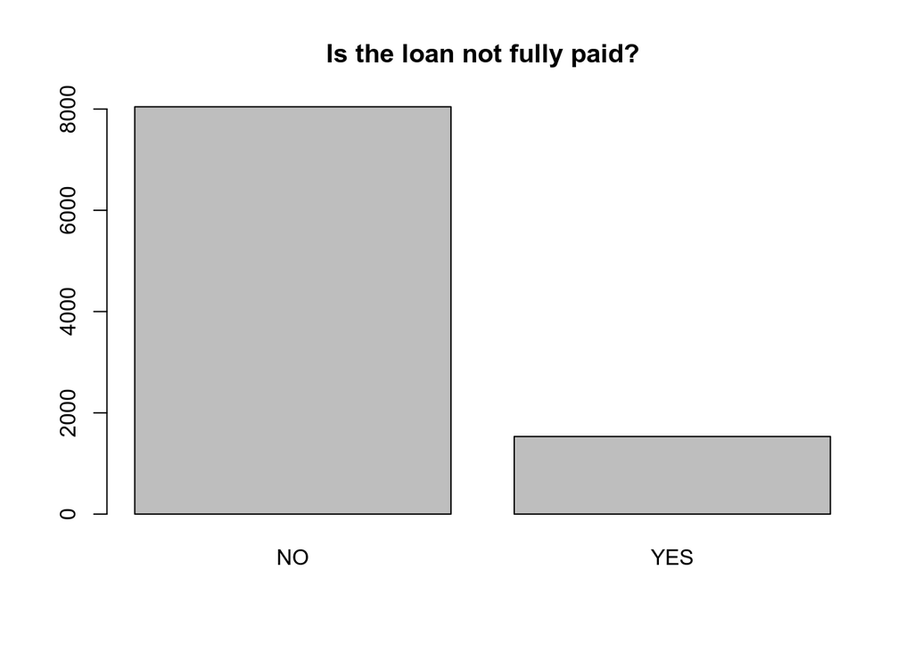

```r
loans <- loans %>%
  mutate(NFP = factor(not_fully_paid, labels = c('NO','YES')))

plot(loans$NFP,main="Is the loan not fully paid?")
```

```r
# proportion of those who did not pay their loans based on purpose of a loan
plot1<-loans %>%
  group_by(purpose) %>%
  count(NFP) %>%
  mutate(prop = n / sum(n)) %>%
  filter(NFP == 'YES') %>%
  ggplot(aes(reorder(purpose, prop), prop, fill = purpose))+
  geom_col()+
  coord_flip()+
  theme_classic()+
  scale_y_continuous(labels = scales::percent_format(accuracy = 5L),expand = c(0,0),breaks=seq(0,0.3,0.05))+
  labs(title="Portion of those who did not Fully Paid based on Purpose of Loans(%)",x="",y="")+
  theme(plot.title = element_text(size = 11, face = "bold",family="serif",hjust = 0))+
  theme(legend.title=element_blank())+
  theme(legend.position="none")+
  scale_fill_manual(values = c("#8C510A","#D8B365","#F6E8C3","#F5F5F5","#C7EAE5","#5AB4AC","#01665E"))+ scale_x_discrete(labels = c("small_business"="Small Business", "educational"="Educational","home_improvement"="Home Improvement","all_other"="All Other","debt_consolidation"="Debt Consolidation","credit_card"="Credit Card","major_purchase"="Major Purchase"))+
 geom_text(aes(label = paste0("n=",n)),position = position_stack(vjust = 0.5), size = 4, color = "black")
```

Although the number of borrowers who got loans for debt consolidation is largest, a higher proportion of borrowers who got a loan but did not fully paid their debt belongs to small business.

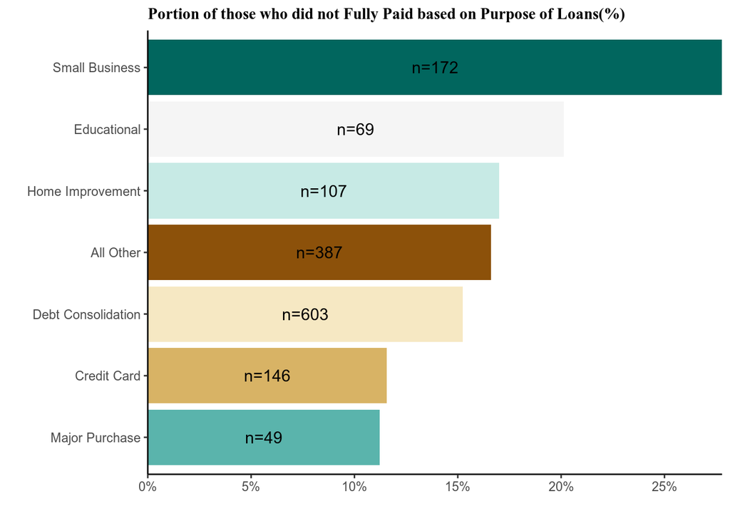

```r
plot1
```

```r
#a comparison between those who paid fully v.s. thos who did not pay

## credit policy
plot2<-loans %>% group_by(NFP) %>% count(credit_policy) %>%
  mutate(prop = n / sum(n)) %>%
  ggplot(aes(reorder(credit_policy, prop), prop)) +
  geom_bar(stat = "identity")+facet_wrap(~NFP)+ aes(fill = as.factor(NFP))+
  scale_y_continuous(labels = scales::percent_format(accuracy = 5L),expand = c(0,0),breaks=seq(0,0.9,0.1))+
  labs(title="1 if the customer meets the credit underwriting criteria; 0 otherwise",x="",y="")+
  theme(plot.title = element_text(size = 11, face = "bold",family="serif",hjust = 0))+
 geom_text(aes(label = paste0("n=",n)),position = position_stack(vjust = 0.5), size = 4, color = "black")+
  theme(legend.title=element_blank())+
  theme(legend.position="none")+theme(strip.background = element_blank())


## interest rate
plot3<-loans %>%
  ggplot(aes(NFP, int_rate, fill = NFP))+
  geom_boxplot()+
  scale_fill_manual(values = c("#E69F00", "#56B4E9"),name="Not Fully\nPaid")+
  theme_classic()+
  labs(title="Interest Rate",x="",y="")+
  theme(plot.title = element_text(size = 11, face = "bold",family="serif",hjust = 0))+
  scale_y_continuous(labels = scales::percent_format(accuracy = 5L),expand = c(0,0),breaks=seq(0,0.25,0.05))

# log annual income
plot4<-loans %>%
  ggplot(aes(log_annual_inc, fill = NFP))+
  geom_density()+
  scale_fill_manual(values = c("#E69F00", "#56B4E9"),name="Not Fully\nPaid")+
  theme_classic()+
  labs(title="Annual Income (log)",x="",y="")+
  theme(plot.title = element_text(size = 11, face = "bold",family="serif",hjust = 0))

# debt to income ratio
plot5<-loans %>%
  ggplot(aes(NFP,dti, fill = NFP))+
  geom_boxplot()+
  scale_fill_manual(values = c("#E69F00", "#56B4E9"),name="Not Fully\nPaid")+
  labs(title="Debt to Income Ratio",x="",y="")+
  theme(plot.title = element_text(size = 11, face = "bold",family="serif",hjust = 0))
```

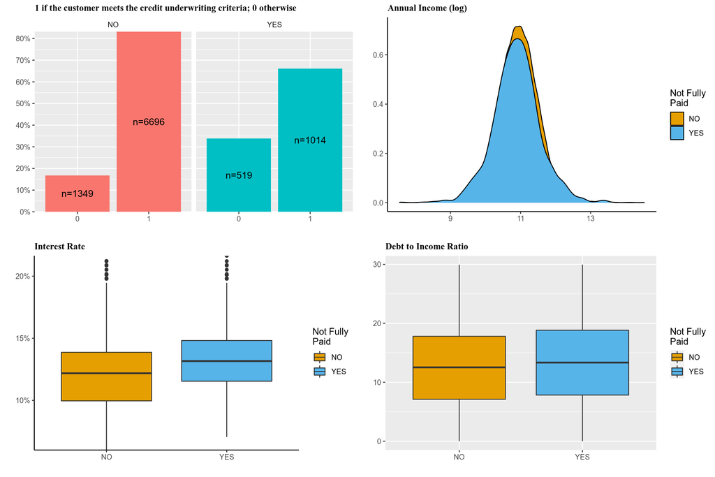

```r
ggarrange(plot2,plot4,plot3,plot5, nrow=2,ncol=2)
```

### Find out how long it takes for users to pay back their loan.

One critical question is that how long it takes for users to pay back their loans. Assuming all borrowers who did not have their balance fully use installment to pay their loans, we can introduce a schedule that how much the bank is expected each month to receive from current customers. We assume no default, all borrowers use installment. We can create other scenarios to evaluate cash flow from those borrowers. The following plots show balance, payment, interest, and principal over the next 30 months for borrowers who did not pay their loans fully.

```r
# Calculate number of months if borrower chose installment

loans1<-subset(loans,revol_util!=0)# drop if loans have been used
loans1$month<-ceiling( ((loans1$revol_bal/(0.01*loans1$revol_util*loans1$installment))) )# calculate number of months if a  borrower chose to pay on installment
loans1<- loans1 %>% filter(month<31)#drop if installment is higher than 30 months!

NFP<- subset(loans1 ,NFP=="YES" & month!=0)# subset those who did not pay fully

suffix <- seq(1:nrow(NFP))
NFP$id<-paste("L",suffix,sep="_") #create an id for each loans for future use
NFP$df<-NA

## following code adopted codes from this link: https://gist.github.com/raqueralt/9d9b9e5cc79f78c6c636aa0cf41de96e
#nest into the dataframe
for (k in 1:nrow(NFP)) {
  C_0 <- NFP$revol_bal[k] #Revolving balance amount
  i <- NFP$int_rate[k]/12 #Monthly Interest rate
  n <- NFP$month[k] #Mortgage term month

  NFP$df[k]<-list(data.frame(Period = 1:(n),
           Payment = C_0/((1-(1 + i)^-n) / i),
           Balance = 0)%>%
  mutate(Balance = accumulate(Balance,  ~.x*(1+i) - Payment[[1]], .init = C_0)[-1], #Calculate Balance
         Principal = lag(Balance, default = first(C_0)) - Balance,                  #Calculate Amortization(Principal)
         Interest = Payment - Principal) %>%                                        #Calculate Interest
  round(2) %>%
  select(Period, Payment, Interest, Principal, Balance) %>%

  add_row(Period = 0, Payment = 0, Interest = 0, Principal = 0, Balance = C_0,.before = 1) )

 }
```

```r
#creating amortization schedule
names<-colnames(NFP[[18]][[1]])
amortization<-data.frame(matrix(ncol=6,nrow=0))
colnames(amortization)<-names

for (i in 1:nrow(NFP)) {
  NFP[["df"]][[i]]$id<-NFP$id[i]
  amortization<-rbind(amortization,NFP[["df"]][[i]])
}
```

```r
options(scipen=999)

bal1<-amortization %>% group_by(Period) %>% summarise_at(c("Balance"),sum) %>%
  ggplot(aes(x=Period,y=Balance))+
  geom_line()+ geom_point(shape=1)+
  theme_classic()+
    labs(x=NULL,y=NULL,title="Borrowers' Revolving Balance")+
    scale_y_continuous(labels = scales::dollar,expand = c(0,0))+
     scale_x_continuous(breaks=seq(0,32,1),expand = c(0,0))+
  theme(plot.title = element_text(size = 10, face = "bold",family="serif"))

amort1<-amortization %>% group_by(Period) %>% summarise_at(c("Payment","Interest","Principal","Balance"),sum)

amort1<-melt(amort1[,c("Period","Payment","Interest","Principal")],id="Period")

bal2<-ggplot(amort1,aes(x=Period,y=value,color=variable),size=1)+
    geom_line()+
    labs(x="Month",y=NULL,title="Borrowers' Amortization Schedule")+ geom_point(shape=1)+
    theme_classic()+
    scale_y_continuous(labels = scales::dollar,expand = c(0,0))+
    scale_x_continuous(breaks=seq(0,32,1),expand = c(0,0))+
    theme(legend.position = "bottom",legend.title=element_blank())+theme(plot.title = element_text(size = 10, face = "bold",family="serif"))
```

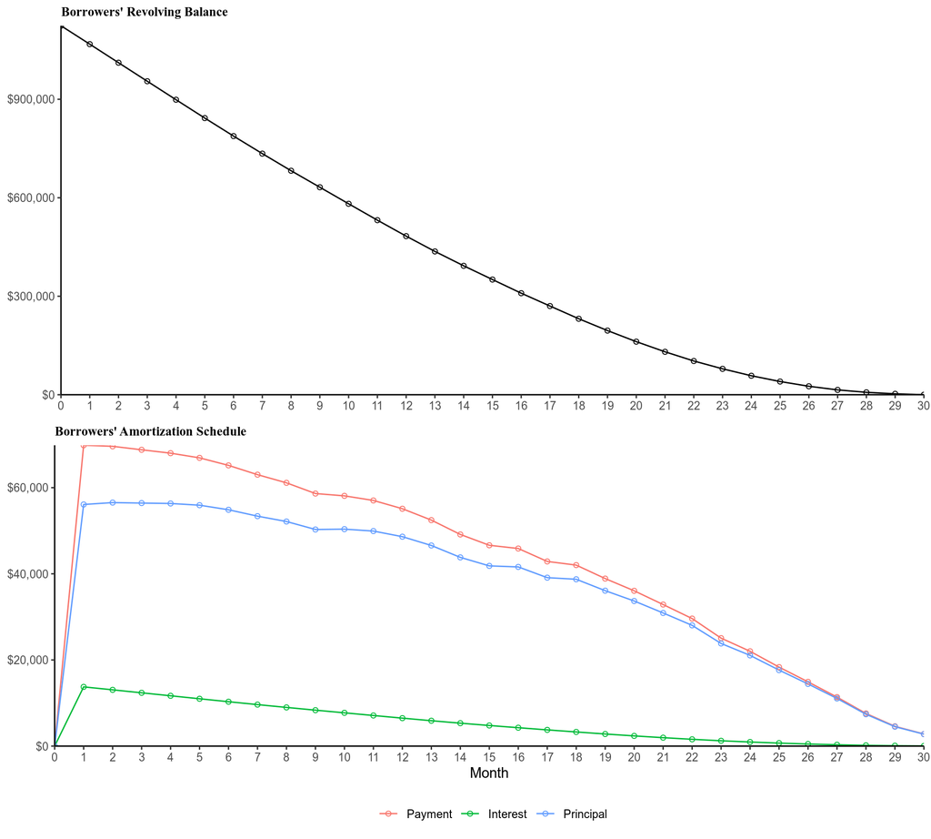

```r
ggarrange(bal1,bal2,nrow=2)
```

### Model

We may want to explore the probability that a borrower pays her loan and see what are underlying factors. In theory, we expect that a borrower who has a higher number of derogatory public records, higher delinquency rate, a higher number of inquiries by creditors, lower FICO score, higher debt to income ratio and did not satisfy the credit underwriting criteria would have a higher probability to not pay the loan. To examine this issue we use logistic regression. We took the following steps to build the model and evaluate to find the most appropriate one:

- dividing groups to test and train
- starting with fit all possible models, excluding just one of the variables at a time. It gives 6 models for our data set
- Calculating AUCs
- choose a model based on regressions (p-value) and AUCs: model 3 and model 4 are appropriate because of variables are significant and have appropriate AUC. Also, they have fewer variables that make interpretation easier.

```r
set.seed(123)

# index_train
index_train<-sample(1:nrow(loans),2 / 3 * nrow(loans))

# Create training set
training_set <- loans[index_train, ]

# Create test set
test_set<- loans[-index_train,]

model1<-glm(not_fully_paid~credit_policy+fico+pub_rec+inq_last_6mths+delinq_2yrs+dti,data=training_set,family = "binomial")#full model
model2<-glm(not_fully_paid~credit_policy+fico+pub_rec+inq_last_6mths+delinq_2yrs,data=training_set,family = "binomial")#drop dti
model3<-glm(not_fully_paid~credit_policy+fico+pub_rec+inq_last_6mths,data=training_set,family = "binomial")#drop delinq_2yrs
model4<-glm(not_fully_paid~credit_policy+fico+pub_rec,data=training_set,family = "binomial")#drop inq_last_6mths
model5<-glm(not_fully_paid~credit_policy+fico,data=training_set,family = "binomial")#drop pub_rec
model6<-glm(not_fully_paid~credit_policy,data=training_set,family = "binomial")#drop fico

# Predictions for each of the models
predict1 <- predict(model1, newdata = test_set, type = "response")
predict2 <- predict(model2, newdata = test_set, type = "response")
predict3 <- predict(model3, newdata = test_set, type = "response")
predict4 <- predict(model4, newdata = test_set, type = "response")
predict5 <- predict(model5, newdata = test_set, type = "response")
predict6 <- predict(model6, newdata = test_set, type = "response")

# ROC-information
ROC_model1 <- roc(test_set$not_fully_paid, predict1)
ROC_model2 <- roc(test_set$not_fully_paid, predict2)
ROC_model3 <- roc(test_set$not_fully_paid, predict3)
ROC_model4 <- roc(test_set$not_fully_paid, predict4)
ROC_model5 <- roc(test_set$not_fully_paid, predict5)
ROC_model6 <- roc(test_set$not_fully_paid, predict6)

# Compute the AUCs
auc1<-auc(ROC_model1)
auc2<-auc(ROC_model2)
auc3<-auc(ROC_model3)
auc4<-auc(ROC_model4)
auc5<-auc(ROC_model5)
auc6<-auc(ROC_model6)

auc<-as.data.frame(rbind(auc1[1],auc2[1],auc3[1],auc4[1],auc5[1],auc6[1]))
colnames(auc)<-"AUC"
rownames(auc)<-c("Model1","Model2","Model3","Model4","Model5","Model6")
```

```r
kable(auc)
```

|  | AUC |
| --- | --- |
| Model1 | 0.6410475 |
| Model2 | 0.6415510 |
| Model3 | 0.6399397 |
| Model4 | 0.6347020 |
| Model5 | 0.6342991 |
| Model6 | 0.5847933 |

**Logistic Regression**

|  | *Dependent variable:* |  |  |  |  |  |
| --- | --- | --- | --- | --- | --- | --- |
|  | not_fully_paid |  |  |  |  |  |
|  | (1) | (2) | (3) | (4) | (5) | (6) |
| credit_policy | -0.364*** | -0.363*** | -0.361*** | -0.667*** | -0.665*** | -0.943*** |
|  | (0.098) | (0.098) | (0.098) | (0.082) | (0.082) | (0.075) |
| fico | -0.009*** | -0.009*** | -0.009*** | -0.009*** | -0.009*** |  |
|  | (0.001) | (0.001) | (0.001) | (0.001) | (0.001) |  |
| pub_rec | 0.221* | 0.222* | 0.224* | 0.277** |  |  |
|  | (0.117) | (0.117) | (0.117) | (0.114) |  |  |
| inq_last_6mths | 0.095*** | 0.095*** | 0.096*** |  |  |  |
|  | (0.016) | (0.016) | (0.016) |  |  |  |
| delinq_2yrs | -0.076 | -0.074 |  |  |  |  |
|  | (0.062) | (0.062) |  |  |  |  |
| dti | -0.002 |  |  |  |  |  |
|  | (0.005) |  |  |  |  |  |
| Constant | 5.097*** | 5.014*** | 4.823*** | 5.053*** | 5.274*** | -0.927*** |
|  | (0.784) | (0.749) | (0.732) | (0.725) | (0.718) | (0.063) |
| Observations | 6,385 | 6,385 | 6,385 | 6,385 | 6,385 | 6,385 |
| Log Likelihood | -2,697.560 | -2,697.624 | -2,698.362 | -2,716.766 | -2,719.596 | -2,759.309 |
| Akaike Inf. Crit. | 5,409.120 | 5,407.247 | 5,406.723 | 5,441.531 | 5,445.191 | 5,522.618 |
| *Note:* | p<0.1; p<0.05; p<0.01 |  |  |  |  |  |

### Future work

The model can help to build more scenarios about probability whether a borrower pays a loan or not. We can create several scenarios to apply in the amortization schedule to have a better understanding that how cash flow will look like given a specific scenario.